# Usage code

# Preface

**This usage code**

- **is part** of the GitHub repository building.map_1920. Check out the [readme file](https://github.com/ukral/building.map_1920/blob/main/README.md) to learn more about the corresponding datasets and how to use and re-use the underlying R Markdown file.
- **is for users** of the datasets who want to use and re-use the datasets.

# 1 Introduction figures

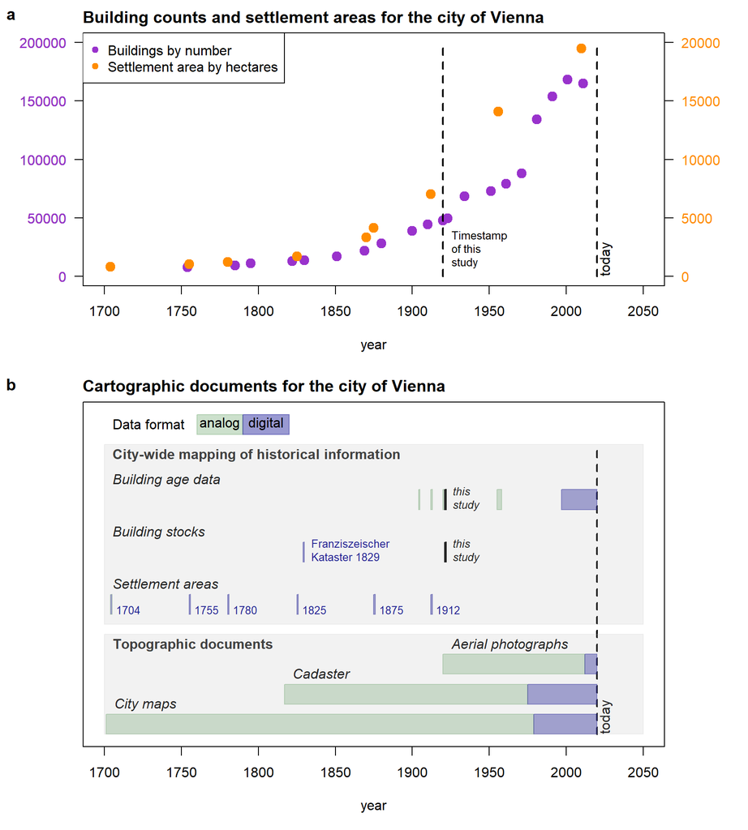

# 2 Scales of analog map sheets

Scales of building stock maps, which were used to retrieve the building footprints: 1:NA, 1:5000, 1:3500, 1:1440, 1:10000, 1:2880. Note: NA stands for “not available”, because the digitial city map is vectorized and therefore doesn’t have a scale.

# 3 Addresss changes

Address changes between ‘Address.2019’ and ‘Address.1920’. Scope: ‘Address_review’ = yes

| address change | affected polygons | ratio [%] |
| --- | --- | --- |
| yes | 13,108 | 26 |
| no | 36,478 | 74 |

# 4 Area of building footprints

The “Area” records are summarized by “UD.1920” and “UD.2020”, respectively, and plotted in the next figure.

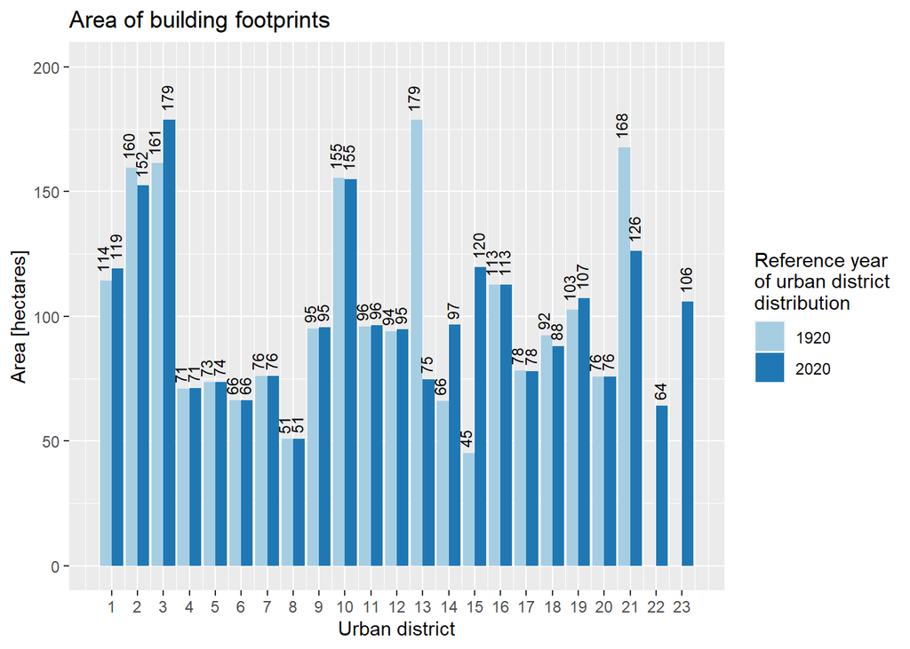

# 5 Data sources to retrieve building footprints

The “Polygon.source_name” records were grouped by “UD.2020”, summarized by “Area” and plotted in the next figure.

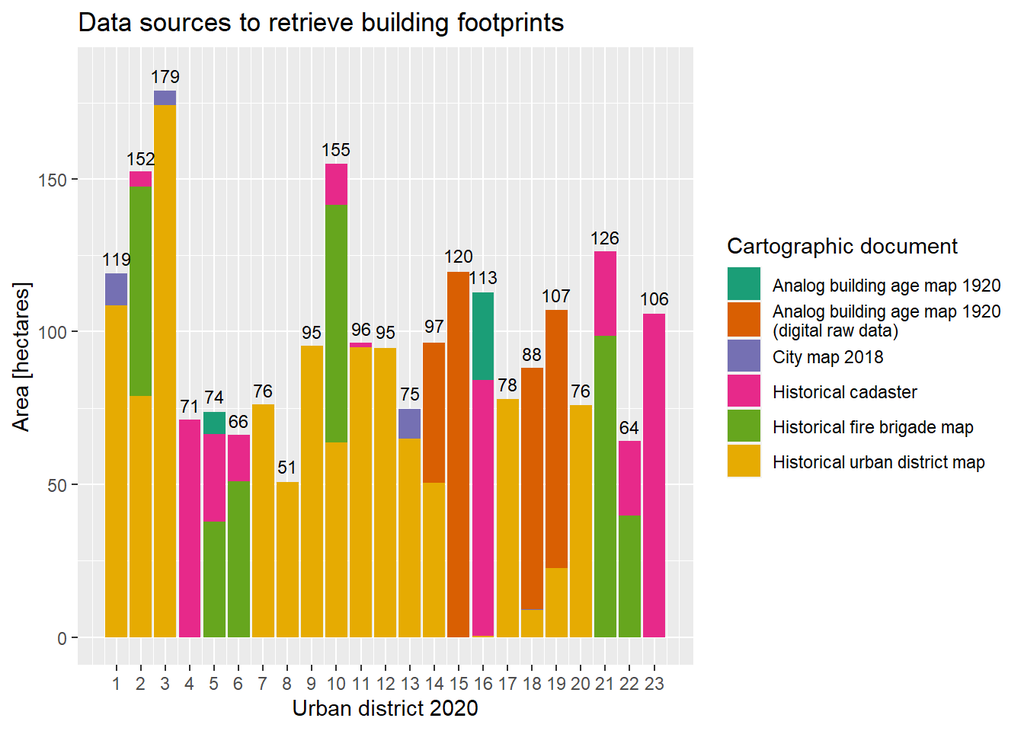

- Number of unique maps sheets: 134. Retrieved from City map 2018, Historical urban district map, Historical fire brigade map, Historical cadaster, Analog building age map 1920, Analog building age map 1920 (digital raw data).
- Number of unique timestamps: 19.

# 6 Editors of vectorized building footprints

The “Editor” records were grouped by “UD.2020”, summarized by “Area” and plotted in the next figure.

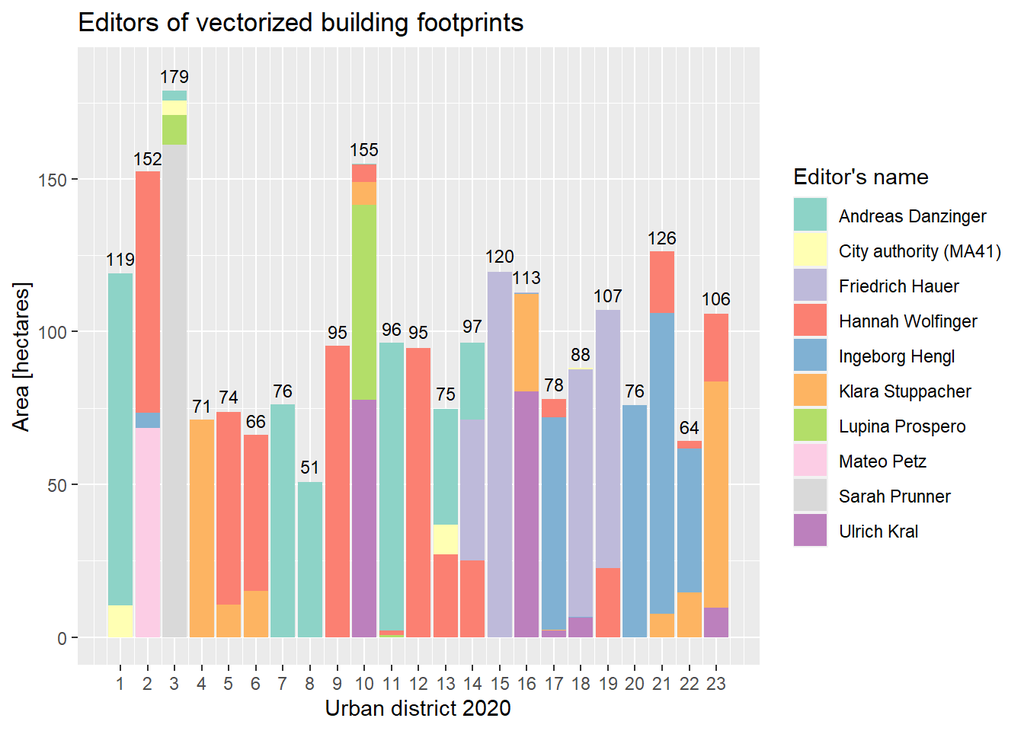

- Number of unique editors: 10.

# 7 Temporal presence of building footprints

The “TP_pub.date_period” records were grouped by “UD.2020”, summarized by “Area” and plotted in the next figure.

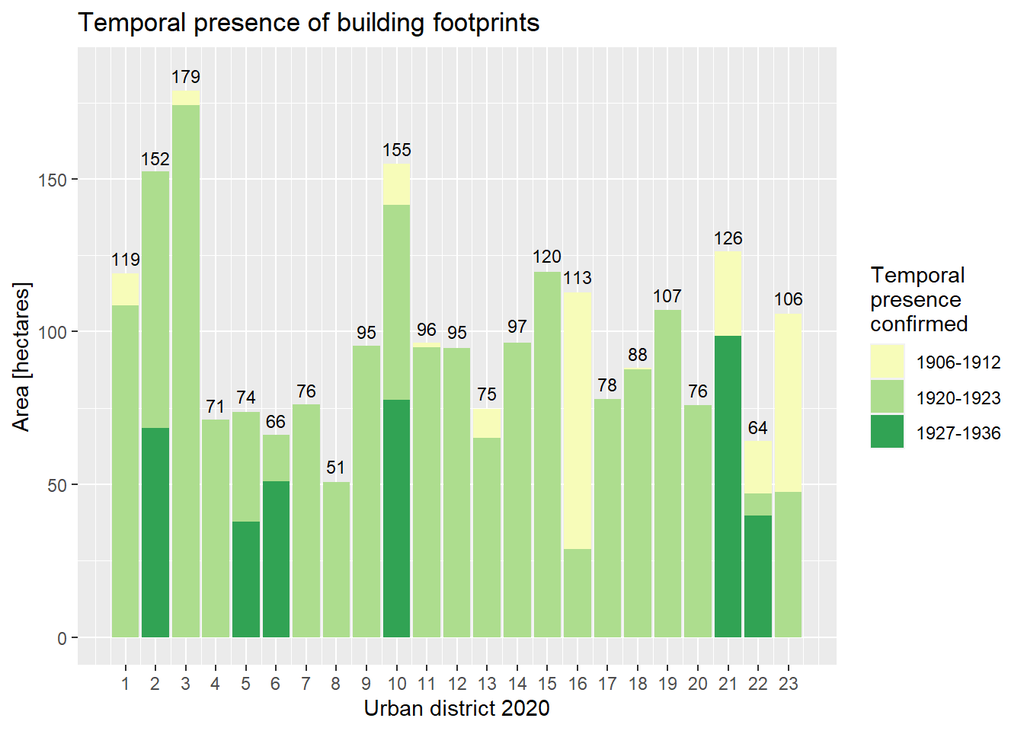

- City-wide data grouped into 3 periods.

  | TP_pub.date_period | sum_area_abs | sum_area_rel |
  | --- | --- | --- |
  | 1906-1912 | 227 | 10 |
  | 1920-1923 | 1,679 | 74 |
  | 1927-1936 | 373 | 16 |

# 8 Period of constrution

The “PoC” records were grouped by two different types of timespan, summarized by “Area” and plotted in the next figure.

```
## [1] CD.bs   min     max     szbg_bp
## <0 Zeilen> (oder row.names mit Länge 0)
```

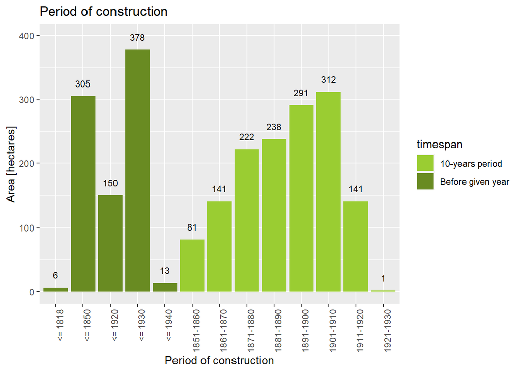

- Summary: Assignment of construction dates.

- Summary: Grouping PoC records.

  | timespan | sum_area | sum_area_rel |
  | --- | --- | --- |
  | 10-years period | 1,428 | 63 |
  | Before given year | 851 | 37 |

- Number of construction date assignments.

  | CD_multiple | count_CD_multiple | count_CD_multiple_rel |
  | --- | --- | --- |
  | 1 | 28,359 | 35 |
  | 2 | 35,233 | 44 |
  | 3 | 17,048 | 21 |

# 9 Data sources to retrieve building construction dates

The “PoC.source_name” records were grouped by “UD.2020”, summarized by “Area” and plotted in the next figure.

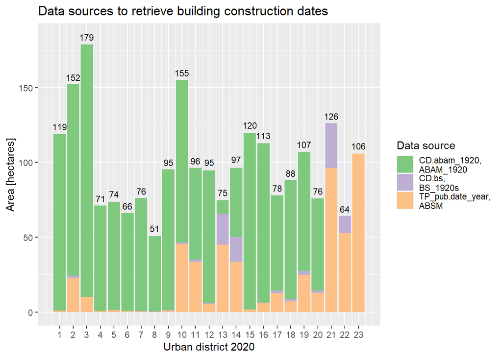

- City-wide data:

  | PoC.source_name | sum_area | sum_area_rel |
  | --- | --- | --- |
  | CD.abam_1920, ABAM_1920 | 1,665 | 73 |
  | CD.bs, BS_1920s | 94 | 4 |
  | TP_pub.date_year, ABSM | 520 | 23 |

# 10 Location of building footprints within city limits 1920

The “Location.city_limits_1920” records were grouped by “UD.2020”, summarized by “Area” and plotted in the next figure.

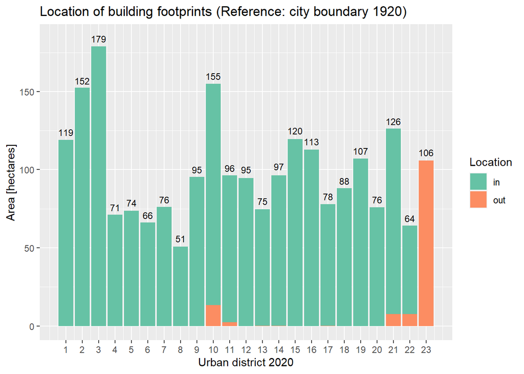

- City-wide data:

  | Location.city_limit_1920 | sum_area | sum_area_rel |
  | --- | --- | --- |
  | in | 2,142 | 94 |
  | out | 137 | 6 |

# 11 Location of building footprints within scope of analog building age map 1920

The “Location.ABAM_1920” records were grouped by “UD.2020”, summarized by “Area” and plotted in the next figure.

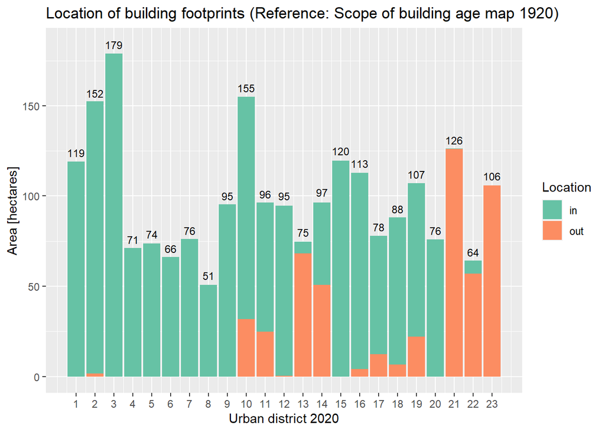

- City-wide data:

  | Location.abam_1920 | sum_area | sum_area_rel |
  | --- | --- | --- |
  | in | 1,767 | 78 |
  | out | 512 | 22 |

# 12 Building counts by urban district

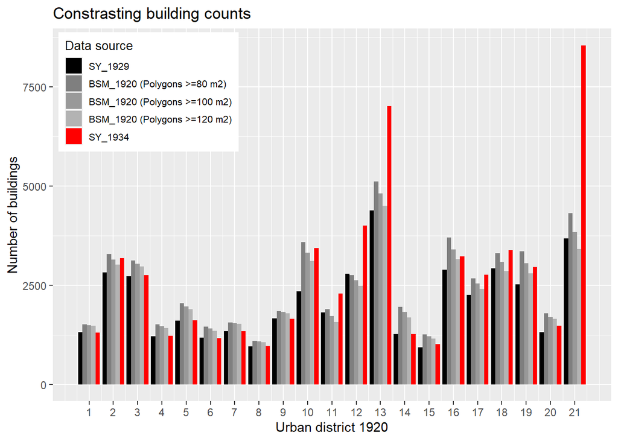

# 13 Building footprint presence in 1920

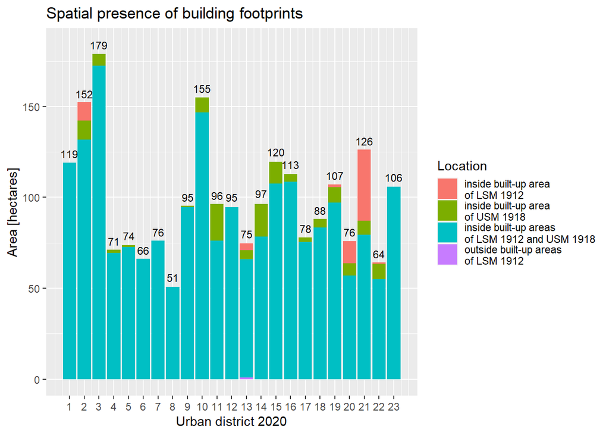

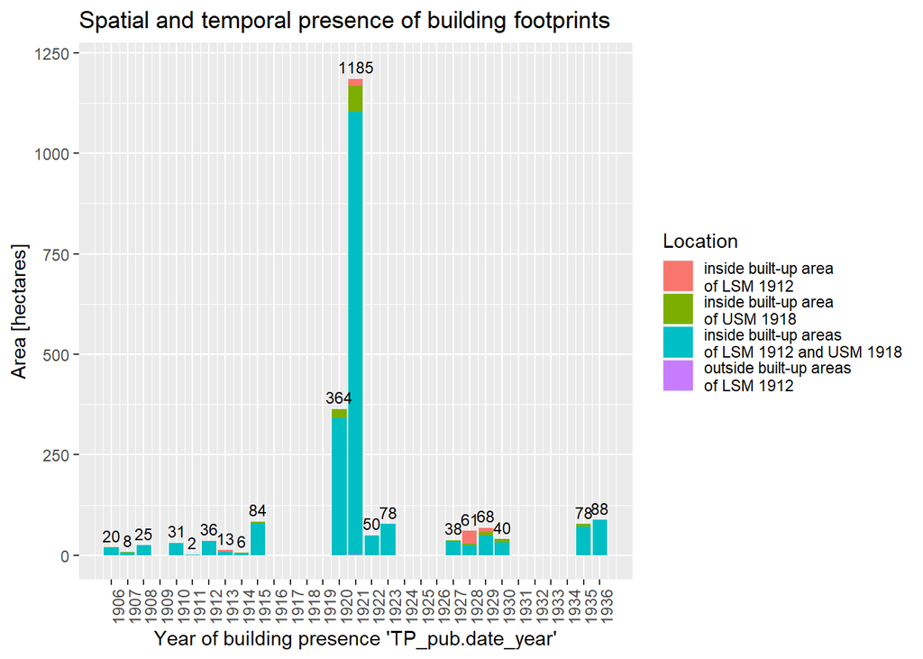

- City-wide data:

  | Presence.conf | sum_area | sum_area_rel |
  | --- | --- | --- |
  | inside built-up area of LSM 1912 | 68 | 3 |
  | inside built-up area of USM 1918 | 127 | 6 |
  | inside built-up areas of LSM 1912 and USM 1918 | 2,083 | 91 |
  | outside built-up areas of LSM 1912 | 1 | 0 |

# 14 Construction years

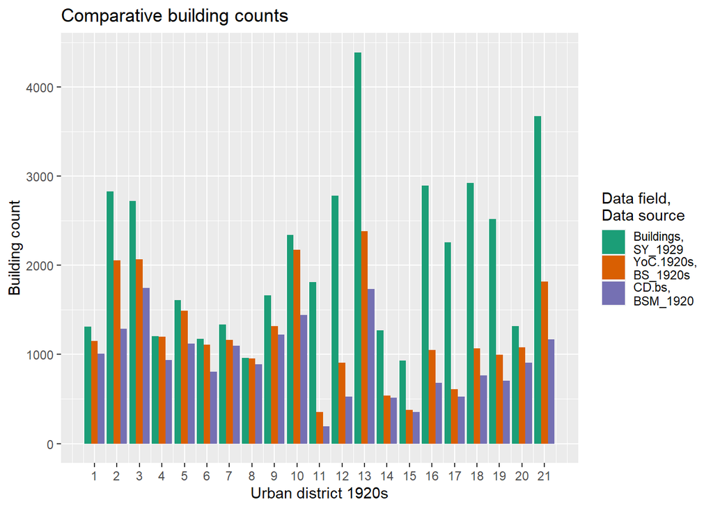

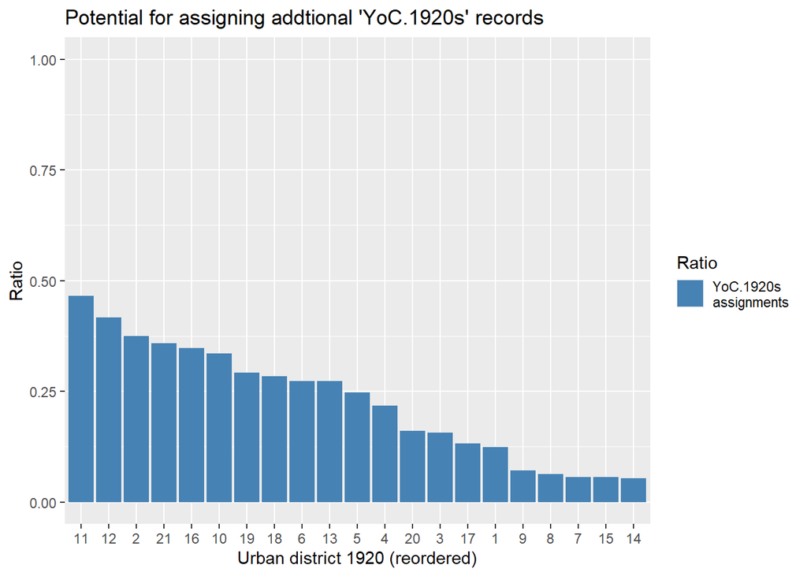

- BS_1920s perspective: : The BS_1920s includes 2.5859^{4}(100%) entries with records in “YoC.1920”, “STR.1920s” and “BN.1920”. The latter two are needed to join the BS_1920s and BSM_1920. The workflow in this study captured 1.9631^{4} (76%) “YoC.1920s” records and assigned them to buildings in BSM_1920. In other words, the remaining potential for assignments is (24%).
- Statistical yearbook (SY_1929) perspective:

  | data_source | count | ratio |
  | --- | --- | --- |
  | CD.bs_BSM_1920 | 19,631 | 45 |
  | SY_1929 | 43,910 | 100 |
  | YoC.1920s_BS_1920s | 25,859 | 59 |

# 15 Construction periods

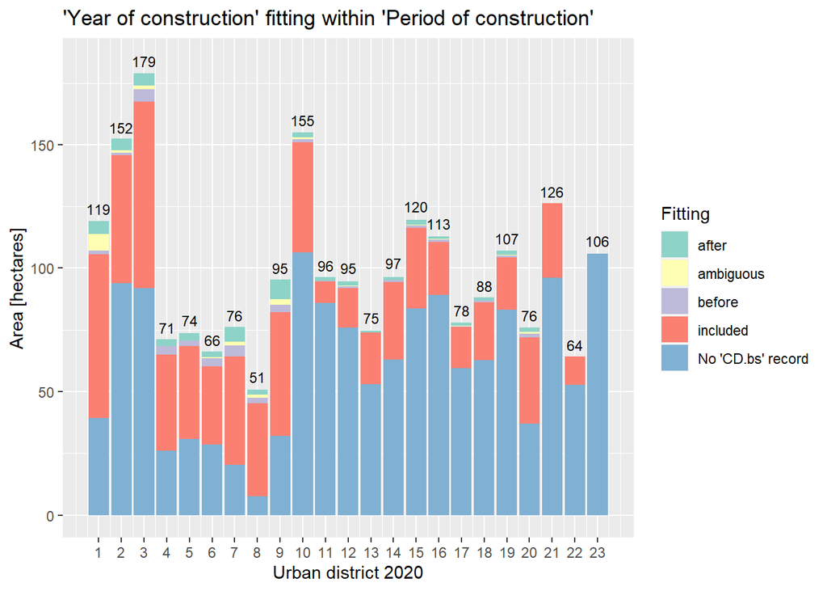

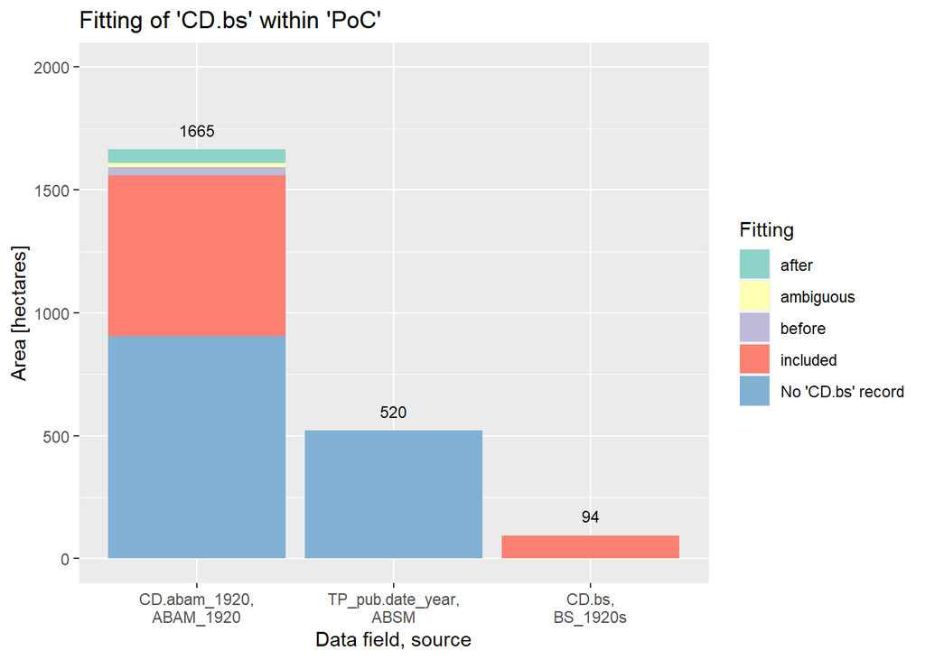

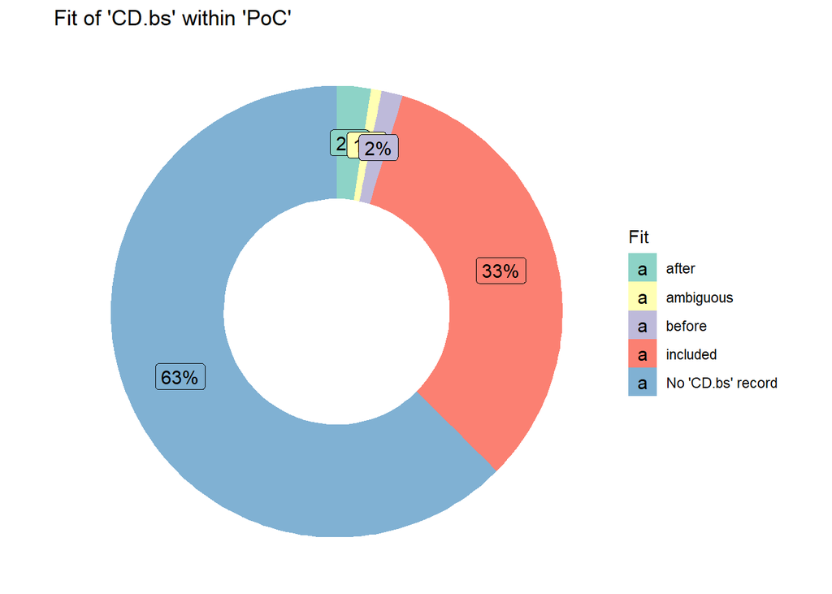

- Summary: The building footprint area is 2279 ha.

  | PoC.source_name | sum_area | sum_area_rel |
  | --- | --- | --- |
  | CD.abam_1920, ABAM_1920 | 1,665 | 73 |
  | CD.bs, BS_1920s | 94 | 4 |
  | TP_pub.date_year, ABSM | 520 | 23 |

- Summary: The building footprint area is 2279 ha.

  | category | sum_area | sum_area_real |
  | --- | --- | --- |
  | after | 56 | 2 |
  | ambiguous | 17 | 1 |
  | before | 35 | 2 |
  | included | 746 | 33 |
  | No ‘CD.bs’ record | 1,425 | 63 |

- Summary: This table is based on data entries that have “PoC” and “CD.bs” records. In other words, blank “CD.bs” records are excluded. The building footprint area is 854 ha, which is 37% of the total area.

  | CD.bs_fit | sum_area | sum_area_rel |
  | --- | --- | --- |
  | after | 56 | 7 |
  | ambiguous | 17 | 2 |
  | before | 35 | 4 |
  | included | 746 | 87 |

# Annnex

## Plotting figures

The figures are published in the corresponding paper.